# Statistical Analysis Report

# 4 Exploratory Data Analysis

## 4.1 Univariate Analysis

### 4.1.1 Numerical Variables

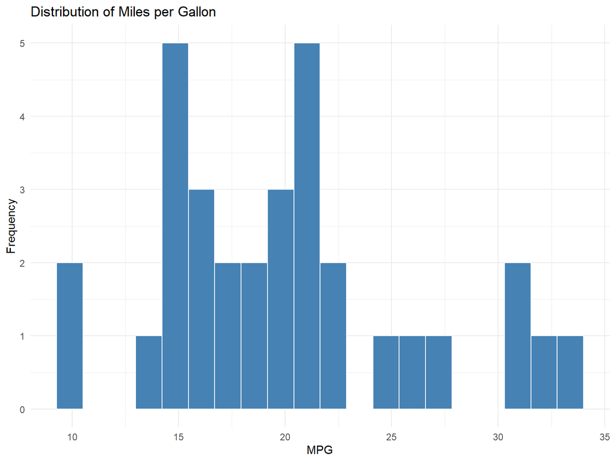

Distribution of numerical variables

```r
# Example: Histogram
data %>%
  ggplot(aes(x = mpg)) +
  geom_histogram(bins = 20, fill = "steelblue", color = "white") +
  labs(title = "Distribution of Miles per Gallon",
       x = "MPG",
       y = "Frequency") +
  theme_minimal()
```

### 4.1.2 Categorical Variables

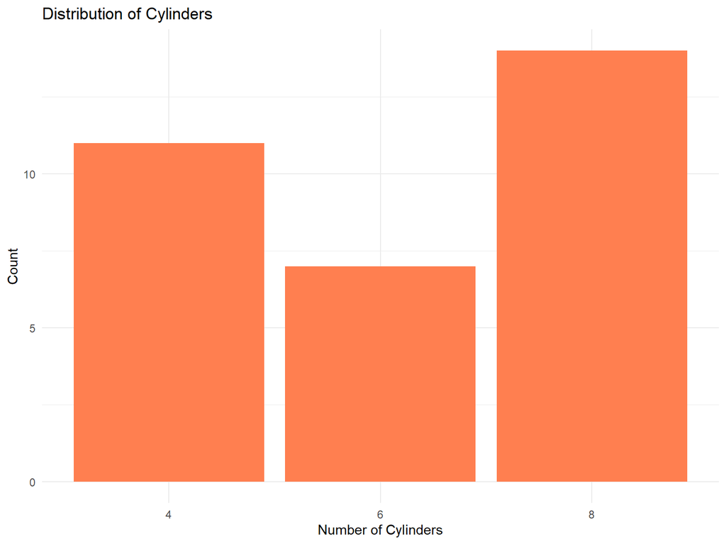

Distribution of categorical variables

```r
# Example: Bar plot
data %>%
  ggplot(aes(x = factor(cyl))) +
  geom_bar(fill = "coral") +
  labs(title = "Distribution of Cylinders",
       x = "Number of Cylinders",
       y = "Count") +
  theme_minimal()
```